# Uma Análise Exploratória do Projeto Ensino Médio e Além (HS&B)

## 1. Introdução

O presente relatório apresenta uma análise exploratória do dataset **hsb2f.csv**, composto por dados coletados por meio de uma pesquisa de base com alunos do último e segundo ano do ensino médio nos Estados Unidos. A primeira survey nacional foi aplicada em 1980. De acordo com o Centro Nacional para Estudos da Educação NCES( s/d). O modelo amostral inicial previa 1.100 escolas com 36 alunos do último ano e 36 do segundo ano por escola. Os instrumentos de pesquisa incluíram: questionário do segundo ano, questionário do último ano, páginas de identificação do aluno, séries de testes cognitivos para cada coorte, questionário escolar, lista de verificação de comentários do professor e questionário dos pais. A pesquisa foi realizada em sequência de 1983 a 1986 e, após um intervalo, em 1992, 1993 e 2015. De acordo com Tatsuoka (1988), até 1986, foram coletados dados de 58.270 estudantes do ensino médio (28.240 veteranos e 30.030 alunos do segundo ano) em 1.015 escolas secundárias. O High School and Beyond Project (em português Projeto Ensino Médio e Além) foi um **estudo longitudinal** dos estudantes do ensino médio e também após o témino de sua formação realizado pelo National Center for Education Statistics (United States Department of Education, 2006). Um *estudo longitudinal* é um tipo de estudo observacional que coleta dados de forma consistente de um mesmo grupo de pessoas ao longo de um período de tempo prolongado. O objetivo é monitorar mudanças de opinião e experiências, identificar problemas, descobrir estratégias para melhorar uma área específica e medir o impacto dessas estratégias (QESTIONPRO, 2024). O dataframe utilizado neste trabalho, denominado **hsb2f.csv** (OPENINTRO, s/d) é uma amostra contendo 200 observações do estudo original, aleatoriamente selecionadas, de características desconhecidas, dos alunos do último ano do ensino médio, originalmente selecionadas das 600 observações utilizadas em Tatsuoka (1988).

## 2. Carregando as bibiotecas

```python
import pandas as pd
import numpy as np
import matplotlib.pyplot as plt
import seaborn as sns
```

## 3. Importando os dados

```python
data = pd.read_csv('~/Library/CloudStorage/OneDrive-Pessoal/Trabalhos 2024/Grupo-3/Dados/hsb2f.csv', sep=';')
df = data.loc[:, data.columns != 'id']
```

### 3.1 Visualizando o dataframe

```python
df
```

|  | genero | raca | clasocial | tipescola | programa | ler | escrever | matematica | ciencias | estsociais |
| --- | --- | --- | --- | --- | --- | --- | --- | --- | --- | --- |
| 0 | masculino | branca | baixa | pública | básico | 57 | 52 | 41 | 47 | 57 |
| 1 | feminino | branca | média | pública | técnico | 68 | 59 | 53 | 63 | 61 |
| 2 | masculino | branca | alta | pública | básico | 44 | 33 | 54 | 58 | 31 |
| 3 | masculino | branca | alta | pública | técnico | 63 | 44 | 47 | 53 | 56 |
| 4 | masculino | branca | média | pública | acadêmico | 47 | 52 | 57 | 53 | 61 |
| ... | ... | ... | ... | ... | ... | ... | ... | ... | ... | ... |
| 195 | feminino | asiática | média | privada | básico | 55 | 59 | 52 | 42 | 56 |
| 196 | feminino | branca | média | pública | técnico | 42 | 46 | 38 | 36 | 46 |
| 197 | feminino | branca | média | privada | básico | 57 | 41 | 57 | 55 | 52 |
| 198 | feminino | branca | média | pública | básico | 55 | 62 | 58 | 58 | 61 |
| 199 | feminino | branca | alta | pública | acadêmico | 63 | 65 | 65 | 53 | 61 |

200 rows × 10 columns

## 4. Análise Descritiva

A análise descritiva é uma técnica de análise de dados que visa resumir, organizar e compreender dados históricos para identificar padrões e relacionamentos. É um dos quatro tipos principais de análise de dados, juntamente com a análise diagnóstica, preditiva e prescritiva (Métricas Boss, 2023). A análise descritiva é usada para:

- Descrever um evento, fenômeno ou resultado;
- Compreender o que aconteceu no passado;
- Acompanhar tendências;
- Identificar medidas de tendência central, dispersão e distribuição dos dados;
- Visualizar padrões; e
- Identificar outliers. A análise descritiva é essencial para explorar e compreender os dados antes de prosseguir para análises mais avançadas (SIRIUS, 2022). Apesar de ser uma ferramenta simples, realizada no início do trabalho com os dados, a análise descritiva pode ter diferentes tipos, e essa classificação depende da quantidade de elementos que serão interpretados. Os três tipos de classificação são:
- Univariada: análise de dados trabalha com apenas uma variável de forma isolada, sem se relacionar com as outras do dataset sendo analisado. Apresenta apenas uma característica;
- Bivariada: análise feita utilizando-se de duas variáveis. O objetivo é investigar a forma que uma variável se comporta em contato com outra, e medir a relação que existe entre as duas.
- Multivariada. análise realizada simultâneamente entre diversos elementos, relacionando-os entre si permitindo obter inderências mais elaboradas.

### 4.1. Análise Descritiva bivariada

Os gráficos a seguir mostrados neste trabalho busca mostrar o relacionamento entre duas variáveis, com o objetivo de identificar possíveis *correlações*, *associações* e *padrões* entre duas variáveis analisadas. Como visto nos parágrafos anteriores, a *análise descritiva bivariada* permite entender como uma variável afeta a outra e pode fornece informações importantes para a tomada de decisões.

#### 4.1.1. Análise descritiva gênero e classe social

Para verificar o perfil da amostra pesquisada, foram cruzados os dados gênero versus classe social. A **Figura 1** demonstra que as classes média e alta são distribuídas igualitariamente entre os gêneros masculino e feminino. No entanto, observa-se que existem mais indivíduos do gênero feminino na classe baixa se comparados ao gênero masculino.

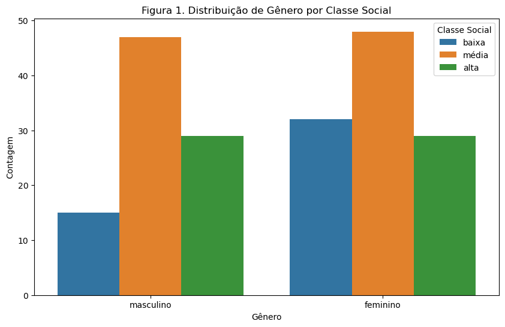

```python
# Gráfico 1: Gênero x Classe Social (contagem)
plt.figure(figsize=(10, 6))
sns.countplot(data=df, x='genero', hue='clasocial')
plt.title('Figura 1. Distribuição de Gênero por Classe Social')
plt.xlabel('Gênero')
plt.ylabel('Contagem')
plt.legend(title='Classe Social')
plt.show()
```

A análise dos dados mostrados na **Figura 1** revela algumas informações interessantes sobre a distribuição socioeconômica entre os gêneros. O fato das classes média e alta serem distribuídas de forma igualitária entre os gêneros sugere uma paridade em oportunidades ou acessos a esses níveis socioeconômicos entre homens e mulheres. Isso pode indicar que, nas camadas sociais mais altas, as barreiras de gênero são menos influentes, ou que ambos os gêneros tiveram acesso semelhante a recursos como educação e emprego. A presença de um número maior de mulheres na classe baixa em comparação com homens pode indicar uma disparidade socioeconômica desfavorável para mulheres em contextos de baixa renda. Isso pode refletir desafios específicos enfrentados por mulheres, como menor acesso a oportunidades de trabalho com boa remuneração, sobrecarga com responsabilidades familiares, ou dificuldades de acesso a educação e capacitação. Essa disparidade pode sugerir a necessidade de políticas ou programas voltados para apoiar mulheres em contextos de baixa renda, promovendo acesso à educação, capacitação profissional e oportunidades no mercado de trabalho. Esses pontos ajudam a dar contexto à análise do perfil da amostra e podem enriquecer a discussão de como gênero e classe social interagem na realidade pesquisada.

#### 4.1.2. Análise descritiva sobre a média de leitura e escrita com o tipo de escola

A média é a medida que mostra o valor de equilíbrio entre as informações numéricas que temos em um conjunto de dados (SIRIUS, 2022). A comparação entre médias de *amostras dependentes*, também chamadas de *amostras emparelhadas*, serve para verificar se a diferença entre as médias é estatisticamente significativa (ALVES, 2022). As amostras dependentes são amostras aleatórias simples. Ambas as populações devem ter distribuição normal. A comparação entre médias de amostras dependentes é útil em diversas situações, como por exemplo, para verificar se um grupo experimental difere de um outro, ou se uma amostra difere da população. O próximo gráfico mostrado neste trabalho busca utilizar as médias relativas à habilidade de leitura dos estudantes sejam diferentes devido ao tipo de escola: pública ou privada. No gráfico mostrado na **Figura 2**, observa-se que a escola privada apresenta uma ligeira melhora na média de leitura e escrita. Esse dado sugere que a escola privada, em comparação com outras instituições, está promovendo um leve aumento na média de desempenho em leitura e escrita entre seus alunos.

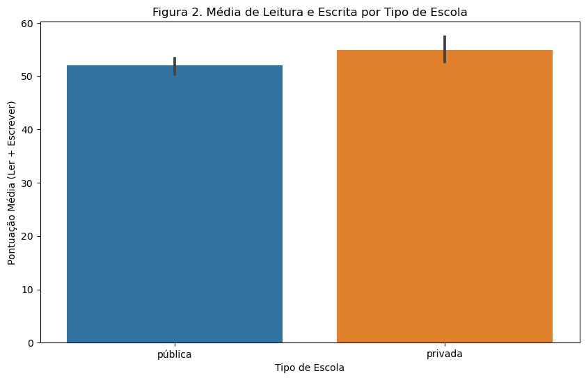

```python
# Gráfico 2: Média de Leitura e Escrita por Tipo de Escola
df['ler_escrever'] = (df['ler'] + df['escrever']) / 2
plt.figure(figsize=(10, 6))
sns.barplot(data=df, x='tipescola', y='ler_escrever')
plt.title('Figura 2. Média de Leitura e Escrita por Tipo de Escola')
plt.xlabel('Tipo de Escola')
plt.ylabel('Pontuação Média (Ler + Escrever)')
plt.show()
```

A priori, essa informação possui possíveis implicações e causas. As escolas privadas frequentemente possuem maior disponibilidade de recursos, tanto materiais quanto humanos, como bibliotecas, laboratórios, materiais didáticos variados e um número reduzido de alunos por turma. Tais fatores possibilitam uma atenção mais individualizada ao aluno, o que pode favorecer o desenvolvimento das habilidades de leitura e escrita. Além disso, a leve vantagem na média de leitura e escrita pode indicar que a escola privada adota práticas pedagógicas focadas em incentivar essas habilidades, como projetos de leitura, atividades de escrita criativa, oficinas literárias, entre outras metodologias ativas. A maior autonomia das escolas privadas para implementar diferentes metodologias pode contribuir para esse resultado. Em geral, alunos de escolas privadas tendem a ter maior acesso a recursos culturais e educacionais fora do ambiente escolar, como livros em casa, cursos de idiomas, acesso à internet e atividades extracurriculares. Esse contexto facilita o desenvolvimento de habilidades verbais, mesmo que a influência não seja exclusiva do ambiente escolar. Embora o desempenho superior em escolas privadas seja esperado, o fato de essa diferença ser leve e não acentuada pode indicar que escolas públicas ou outras instituições também estão conseguindo resultados positivos, especialmente se forem escolas com programas específicos de incentivo à leitura e escrita. Portanto, tais fatores podem ajudar a explicar o motivo pelo qual a escola privada apresenta essa leve melhora, mas também evidenciam que a diferença não é substancial, o que é um ponto positivo para o sistema público ou outras redes de ensino. Essa análise pode ser útil para compreender os fatores que podem contribuir para melhorias nas habilidades de leitura e escrita em diferentes contextos educacionais.